# act_report

## Report: Visualization Report

**Prepared by Henry Adeyemi**

[figure not shown]

*A cute looking dog (1000/10)*

## Introduction

This project analyses data from a Twitter account named [@dog_rates](https://twitter.com/dog_rates). WeRateDogs is a Twitter account that rates people's dogs with a humorous comment about the dog.

WeRateDogs rates various images (i.e. the account does not rate only Dogs), for this report to create a trustworthy analyses; those ratings that were different from that of a dog were filtered out.

This Report highlights some insights & Visualization that were generated after the Data Wrangling process was completed.

### Visualization

These are some insights that were generated from WeRateDogs Twitter Data.

The visualizations were structured to answer specific questions about Dogs and WeRateDogs account

## Insights:

### Which Dog breeds is the most loved judging by the Favorite Count?

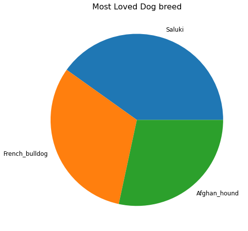

The analysis shows us that if we are to judge by the favourite_counts of the WeRateDogs Twitter; we see visually that the top three Dogs are:

1. Saluki (Known as sighthounds – hunting by sight more than scent or sound)
2. French Bulldog (The head is square shaped and large, with ears that resemble bat ears with a flat-face.
3. Afghan Hound (Distinguished by its thick, fine, silky coat and its tail with a ring curl at the end)

### What sort of correlation exist between the Retweets_Counts & Favourite_counts?

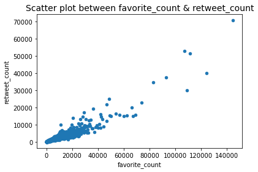

The Scatter Plot above shows us that there is positive correlation between Favorite Count & Retweet Count. (this may mean that the higher the Favorite Count; the higher the Retweet Count)

We can not make conclusions solely on a Scatter Plot, therefore a **Pearson correlation coefficient** was calculated between both indicators; this shows us a 92% correlation (which is very strong).

### Which Dog_Breeds were highly rated by WeRateDogs?

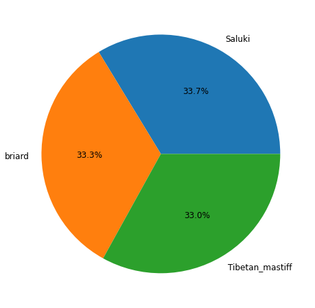

*WeRateDogs Average Rating*

The analysis shows us WeRateDogs rated some dog higher than others; we see visually that the top rated dogsare:

1. Saluki (Known as sighthounds – hunting by sight more than scent or sound). Apparentely this particular Dogs gets so much love! I am jealous.
2. Briard (a shepherd dog, traditionally used both for herding sheep and to defend them)
3. Tibetan Mastiff (Considered a primitive breed)

Although there is a difference between the average ratings of these dogs; we see that the difference is not so much.

## Conclusion

It was an exciting time working on this project, I got to learn more about Data Wrangling and the essense of having proper documentation for all the steps taken during the Wrangling Process. I also got to learn more about dogs! I might just get one for myself soon.